# STA 518 Final Project

Author

Binju Karki, Nour Gaboussa & Sam Kiel

## Overview

In this project we will look at state census data and state presidential election data. When looking at the two together, data is from 2008-2016. Overall census data is from 2008 to 2023 (excluding 2020). Overall election data is from 1976 to 2020. When discussing whether or not a party won a state, won is referring to having a greater number of votes, comparatively.

`state_census` data pulled from GitHub (dilernia, STA 418-518) who gathered it from the `tidycensus` R package and the United States Census website.

`state_election` data pulled from GitHub (dilernia, STA 418-518) who gathered it from MIT Election Data and Science Lab. The reference is below:

MIT Election Data and Science Lab, 2017, “U.S. President 1976–2020”, https://doi.org/10.7910/DVN/42MVDX, Harvard Dataverse, V6, UNF:6:4KoNz9KgTkXy0ZBxJ9ZkOw== [fileUNF]

## Importing packages

```r
library(tidyverse)
library(skimr)
library(knitr)
library(janitor)
library(ggplot2)
library(dplyr)
library(stringr)
library(flextable)
library(ggpubr)
library(lubridate)
library(leaflet)
library(maps)
```

## Looking at the Data

### loading the state census and state election data

```r
# loading the state census data - tidycensus R package and the United States Census website
state_census <- read.csv("https://raw.githubusercontent.com/dilernia/STA418-518/main/Data/census_data_state_2008-2023.csv")

# loading the state election data - MIT Election Data and Science Lab, 2017, “U.S. President 1976–2020”, https://doi.org/10.7910/DVN/42MVDX, Harvard Dataverse, V6, UNF:6:4KoNz9KgTkXy0ZBxJ9ZkOw== [fileUNF]
state_election <- read.csv("https://raw.githubusercontent.com/dilernia/STA418-518/main/Data/1976-2020-president.csv")
```

### Missing values - state census data

```r
skim(state_census)
```

[output not shown]

There are no missing values that we need to be concerned with.

### Missing values - state election data

```r
skim(state_election)
```

[output not shown]

There are a few `writein` missing values; however, we are not concerned as there are only a small number (3/4287). Every observation is missing the `notes` feature, so we will not use this in our analysis. It appears that some of the values of the `candidate` and `party_detailed` are blank but are not counted as missing. With a quick look, these observations have “OTHER” listed in `party_simiplified`. On a quick glance, these observations also appear to have a lower number in their `candidatevotes` compared to other parties.

### Merging the data

```r
# addressing inconsistencies between data sets in character data

state_census <- state_census |>
  mutate(county_state = str_to_lower(county_state))

state_election <- state_election |>
  mutate(state = str_to_lower(state))

# joining the data

data <- inner_join(state_census, state_election, by = c("county_state" = "state",
                                                        "year" = "year"))
```

### Missing values - merged data

```r
skim(data)
```

Data summary

| Name | data |
| --- | --- |
| Number of rows | 1012 |
| Number of columns | 39 |
| _______________________ |  |
| Column type frequency: |  |
| character | 6 |
| logical | 2 |
| numeric | 31 |
| ________________________ |  |
| Group variables | None |

**Variable type: character**

| skim_variable | n_missing | complete_rate | min | max | empty | n_unique | whitespace |
| --- | --- | --- | --- | --- | --- | --- | --- |
| county_state | 0 | 1 | 4 | 20 | 0 | 51 | 0 |
| state_po | 0 | 1 | 2 | 2 | 0 | 51 | 0 |
| office | 0 | 1 | 12 | 12 | 0 | 1 | 0 |
| candidate | 0 | 1 | 0 | 32 | 113 | 76 | 0 |
| party_detailed | 0 | 1 | 0 | 30 | 130 | 71 | 0 |
| party_simplified | 0 | 1 | 5 | 11 | 0 | 4 | 0 |

**Variable type: logical**

| skim_variable | n_missing | complete_rate | mean | count |
| --- | --- | --- | --- | --- |
| writein | 0 | 1 | 0.11 | FAL: 904, TRU: 108 |
| notes | 1012 | 0 | NaN | : |

**Variable type: numeric**

| skim_variable | n_missing | complete_rate | mean | sd | p0 | p25 | p50 | p75 | p100 | hist |
| --- | --- | --- | --- | --- | --- | --- | --- | --- | --- | --- |
| geoid | 0 | 1 | 28.42 | 15.76 | 1.00 | 15.00 | 28.00 | 41.00 | 56.00 | ▇▇▇▇▇ |
| year | 0 | 1 | 2011.98 | 3.32 | 2008.00 | 2008.00 | 2012.00 | 2016.00 | 2016.00 | ▇▁▇▁▇ |
| population | 0 | 1 | 6506977.24 | 7039620.81 | 532668.00 | 1855413.00 | 4723723.00 | 7288000.00 | 39250017.00 | ▇▂▁▁▁ |
| median_income | 0 | 1 | 54930.91 | 9415.15 | 37095.00 | 47778.00 | 54026.00 | 60656.00 | 78945.00 | ▃▇▇▃▂ |
| median_monthly_rent_cost | 0 | 1 | 874.73 | 198.05 | 528.00 | 715.00 | 840.00 | 976.00 | 1483.00 | ▆▇▆▂▁ |
| median_monthly_home_cost | 0 | 1 | 1124.31 | 344.24 | 494.00 | 847.00 | 1099.00 | 1358.00 | 1957.00 | ▃▇▇▃▂ |
| prop_female | 0 | 1 | 0.51 | 0.01 | 0.47 | 0.50 | 0.51 | 0.51 | 0.53 | ▁▁▆▇▁ |
| prop_male | 0 | 1 | 0.49 | 0.01 | 0.47 | 0.49 | 0.49 | 0.50 | 0.53 | ▁▇▆▁▁ |
| prop_white | 0 | 1 | 0.77 | 0.14 | 0.25 | 0.69 | 0.80 | 0.87 | 0.96 | ▁▁▃▆▇ |
| prop_black | 0 | 1 | 0.11 | 0.11 | 0.00 | 0.03 | 0.06 | 0.16 | 0.53 | ▇▃▁▁▁ |
| prop_native | 0 | 1 | 0.01 | 0.03 | 0.00 | 0.00 | 0.01 | 0.01 | 0.15 | ▇▁▁▁▁ |
| prop_asian | 0 | 1 | 0.04 | 0.06 | 0.01 | 0.01 | 0.03 | 0.05 | 0.38 | ▇▁▁▁▁ |
| prop_hawaiin_islander | 0 | 1 | 0.00 | 0.01 | 0.00 | 0.00 | 0.00 | 0.00 | 0.10 | ▇▁▁▁▁ |
| prop_other_race | 0 | 1 | 0.03 | 0.03 | 0.00 | 0.01 | 0.02 | 0.04 | 0.14 | ▇▃▁▁▁ |
| prop_multi_racial | 0 | 1 | 0.03 | 0.03 | 0.01 | 0.02 | 0.02 | 0.03 | 0.24 | ▇▁▁▁▁ |
| prop_highschool | 0 | 1 | 0.24 | 0.04 | 0.15 | 0.22 | 0.24 | 0.27 | 0.34 | ▂▅▇▅▁ |
| prop_GED | 0 | 1 | 0.04 | 0.01 | 0.02 | 0.04 | 0.04 | 0.05 | 0.07 | ▃▇▅▂▂ |
| prop_some_college | 0 | 1 | 0.06 | 0.01 | 0.03 | 0.06 | 0.06 | 0.07 | 0.09 | ▁▃▇▅▂ |
| prop_college_no_degree | 0 | 1 | 0.15 | 0.02 | 0.09 | 0.14 | 0.15 | 0.17 | 0.22 | ▂▅▇▅▁ |
| prop_associates | 0 | 1 | 0.08 | 0.02 | 0.03 | 0.07 | 0.08 | 0.09 | 0.14 | ▁▂▇▃▁ |
| prop_bachelors | 0 | 1 | 0.19 | 0.03 | 0.10 | 0.17 | 0.19 | 0.21 | 0.25 | ▁▅▇▇▃ |
| prop_masters | 0 | 1 | 0.08 | 0.02 | 0.04 | 0.06 | 0.07 | 0.09 | 0.21 | ▇▅▂▁▁ |
| prop_professional | 0 | 1 | 0.02 | 0.01 | 0.01 | 0.02 | 0.02 | 0.02 | 0.09 | ▇▁▁▁▁ |
| prop_doctoral | 0 | 1 | 0.01 | 0.01 | 0.01 | 0.01 | 0.01 | 0.01 | 0.04 | ▇▂▁▁▁ |
| prop_poverty | 0 | 1 | 0.14 | 0.03 | 0.07 | 0.11 | 0.13 | 0.16 | 0.24 | ▃▇▅▂▁ |
| state_fips | 0 | 1 | 28.42 | 15.76 | 1.00 | 15.00 | 28.00 | 41.00 | 56.00 | ▇▇▇▇▇ |
| state_cen | 0 | 1 | 54.86 | 26.05 | 11.00 | 34.00 | 55.00 | 83.00 | 95.00 | ▆▅▆▃▇ |
| state_ic | 0 | 1 | 40.84 | 22.64 | 1.00 | 23.00 | 43.00 | 62.00 | 82.00 | ▆▆▇▇▅ |
| candidatevotes | 0 | 1 | 392634.82 | 915523.69 | 11.00 | 2683.50 | 13701.00 | 263249.00 | 8753788.00 | ▇▁▁▁▁ |
| totalvotes | 0 | 1 | 2780373.23 | 2689998.27 | 250701.00 | 783758.00 | 2051685.00 | 3378821.00 | 14181595.00 | ▇▂▁▁▁ |
| version | 0 | 1 | 20210113.00 | 0.00 | 20210113.00 | 20210113.00 | 20210113.00 | 20210113.00 | 20210113.00 | ▁▁▇▁▁ |

We used an inner join so that all of our observations would have data from both data sets. This substantially decreased our number of observations so that we are only able to compare 3 election years. The only missing value in our observations is in the `notes` feature, which we will not use. Again, with a quick look, these observations have “OTHER” listed in `party_simiplified`. On a quick glance, these observations also appear to have a lower number in their `candidatevotes` compared to other parties.

### Data Dictionary - merged data

[output not shown]

## Summary Statistics

```r
data <- data |>
  mutate(party_clean = str_replace_all(party_simplified, "[^A-Za-z]", ""),
         party_clean = str_to_title(party_clean))

# adding in a feature for income bracket. which will be used later
data <- data |>
  mutate(income_bracket = case_when(
    median_income <= 40000 ~ "< $40K",
    median_income <= 60000 & median_income > 40000 ~ "$40k–$59K",
    median_income <= 80000 & median_income > 60000 ~ "$60K–$79K",
    median_income > 80000 ~ "$80K+",
    TRUE ~ "Unknown"
  ))
```

```r
# Reference: https://ardata-fr.github.io/flextable-book/header-and-footer.html
# Reference: https://stackoverflow.com/questions/60507139/adding-title-to-the-table-with-flextable-and-officer-library

# creating a data frame that gives the state_election information for the party with the most votes in that state & year
highest_by_state_year <- data |>
  group_by(year, county_state) |>
  filter(candidatevotes == max(candidatevotes))

# looking at the average median income and standard deviation median income for the above data frame
highest_by_state_year |>
  group_by("party" = party_clean) |>
  summarise("mean" = round(mean(median_income), 2),
            "standard deviation" = round(sd(median_income), 2),
            "number of observations" = length(median_income)) |>
  flextable() |>
  add_header_lines("Table 1: Summary Statistics of Median Income by Party When the Party Won the State") |>
  add_footer_lines("Data source: tidycensus R package, United States Census & MIT Election Data and Science Lab") |>
  theme_vanilla()
```

| Table 1: Summary Statistics of Median Income by Party When the Party Won the State party | Table 1: Summary Statistics of Median Income by Party When the Party Won the State mean | Table 1: Summary Statistics of Median Income by Party When the Party Won the State standard deviation | Table 1: Summary Statistics of Median Income by Party When the Party Won the State number of observations |
| --- | --- | --- | --- |
| Democrat | 58,697.66 | 8,988.66 | 77 |
| Republican | 49,387.87 | 7,339.51 | 76 |

Data source: tidycensus R package, United States Census & MIT Election Data and Science Lab

```r
#Reference: https://stackoverflow.com/questions/49500569/using-regular-expressions-in-r-to-grab-numbers-from-a-string

# changing year to a character string value so that it doesn't display with a comma
data <- data |>
  mutate(year = make_date(year = year),
         year = str_remove_all(year, pattern = "-01-01"))

# summarizing the mean and median total votes by the year for 2008-2016
vote_summary <- data |>
  group_by(year) |>
  summarise(mean_votes = round(mean(totalvotes), 0),
            median_votes = median(totalvotes),
            .groups = "drop")

vote_summary |>
  flextable() |>
  add_header_lines("Table 2: Average and Median State Total Votes by Election Year") |>
  add_footer_lines("Data source: MIT Election Data and Science Lab") |>
  theme_vanilla()
```

| Table 2: Average and Median State Total Votes by Election Year year | Table 2: Average and Median State Total Votes by Election Year mean_votes | Table 2: Average and Median State Total Votes by Election Year median_votes |
| --- | --- | --- |
| 2008 | 2,828,162 | 1,960,761 |
| 2012 | 2,783,162 | 1,994,065 |
| 2016 | 2,729,199 | 2,103,027 |

Data source: MIT Election Data and Science Lab

```r
# summarizing the average vote share for each income bracket and party
vote_share_summary <- data |>
  mutate(vote_share = candidatevotes / totalvotes) |>
  group_by("party" = party_clean, "income bracket" = income_bracket) |>
  summarise(
    "vote share (average)" = round(mean(vote_share, na.rm = TRUE), 3),
    "n elections" = n(),
    .groups = "drop"
  )

  vote_share_summary |>
  flextable() |>
  add_header_lines("Table 3: Average Party Vote Share by Party and Income Bracket") |>
  add_footer_lines("Data source: tidycensus R package, United States Census & MIT Election Data and Science Lab") |>
  theme_vanilla()
```

| Table 3: Average Party Vote Share by Party and Income Bracket party | Table 3: Average Party Vote Share by Party and Income Bracket income bracket | Table 3: Average Party Vote Share by Party and Income Bracket vote share (average) | Table 3: Average Party Vote Share by Party and Income Bracket n elections |
| --- | --- | --- | --- |
| Democrat | $40k–$59K | 0.456 | 113 |
| Democrat | $60K–$79K | 0.542 | 38 |
| Democrat | < $40K | 0.421 | 4 |
| Libertarian | $40k–$59K | 0.018 | 99 |
| Libertarian | $60K–$79K | 0.022 | 36 |
| Libertarian | < $40K | 0.004 | 3 |
| Other | $40k–$59K | 0.005 | 398 |
| Other | $60K–$79K | 0.008 | 152 |
| Other | < $40K | 0.003 | 15 |
| Republican | $40k–$59K | 0.507 | 112 |
| Republican | $60K–$79K | 0.380 | 38 |
| Republican | < $40K | 0.565 | 4 |

Data source: tidycensus R package, United States Census & MIT Election Data and Science Lab

```r
state_election <- state_election |>
  mutate(election_decade = floor_date(ymd(paste0(year, "-01-01")), unit = "10 years"),
         election_decade = str_remove_all(election_decade, pattern = "-01-01"))
# Summarize total votes per party and decade
decade_summary <- state_election |>
  filter(party_simplified %in% c("REPUBLICAN", "DEMOCRAT"), !(election_decade %in% c("1970-01-01", "2020-01-01"))) |>
  group_by(election_decade, party_simplified) |>
  summarise(
    total_votes = sum(candidatevotes, na.rm = TRUE),
    .groups = "drop"
  )
flextable(decade_summary) |>
  add_header_lines("Table 4: Total Presidential Candidate Votes by Decade for 1980s-2010s") |>
  add_footer_lines("Data source: MIT Election Data and Science Lab") |>
  theme_vanilla()
```

[output not shown]

Data source: MIT Election Data and Science Lab

```r
# Reference: https://www.reddit.com/r/rstats/comments/6sx3t7/stringr_str_replace_all_and_blank_inputs/

# Clean candidate names and extract last names
data <- data |>
  mutate(candidate_clean = str_to_title(str_trim(candidate)) ,
         candidate_last = word(candidate_clean, 1),
         candidate_last = str_remove_all(candidate_last, ",")) # extract last name

# Group summary: top last names and total votes
last_name_summary <- data |>
  group_by(year, candidate_last) |>
  summarise(
    total_votes = sum(candidatevotes, na.rm = TRUE),
    mean_votes = mean(candidatevotes),
    median_votes = median(candidatevotes),
    .groups = "drop") |>
  arrange(desc(total_votes)) |>
  slice_head(n = 5)

last_name_summary |>
  flextable() |>
  add_header_lines("Table 5: Top 5 Candidate First Names by Total Votes") |>
  add_footer_lines("Data source: MIT Election Data and Science Lab") |>
  theme_vanilla()
```

[output not shown]

Data source: MIT Election Data and Science Lab

```r
# Reference: https://davidgohel.github.io/flextable/reference/width.html

# mean proportion of votes to the total population for Michigan for elections from 2008 to 2016 by party
data <- data |>
  mutate(prop_votes_to_population = candidatevotes / population)

data |>
  filter(county_state == "michigan") |>
  group_by("Party" = party_clean) |>
  summarise("Proportion of population (average)" = mean(prop_votes_to_population)) |>
  flextable() |>
  width(width = 2) |>
  add_header_lines("Table 6: Average proportion of votes to the total population for Michigan from 2008 - 2016 by Party") |>
  add_footer_lines("Data source: tidycensus R package, United States Census & MIT Election Data and Science Lab") |>
  theme_vanilla()
```

| Table 6: Average proportion of votes to the total population for Michigan from 2008 - 2016 by Party Party | Table 6: Average proportion of votes to the total population for Michigan from 2008 - 2016 by Party Proportion of population (average) |
| --- | --- |
| Democrat | 0.258388518 |
| Libertarian | 0.009854351 |
| Other | 0.001706518 |
| Republican | 0.216138769 |

Data source: tidycensus R package, United States Census & MIT Election Data and Science Lab

## Data Visualizations

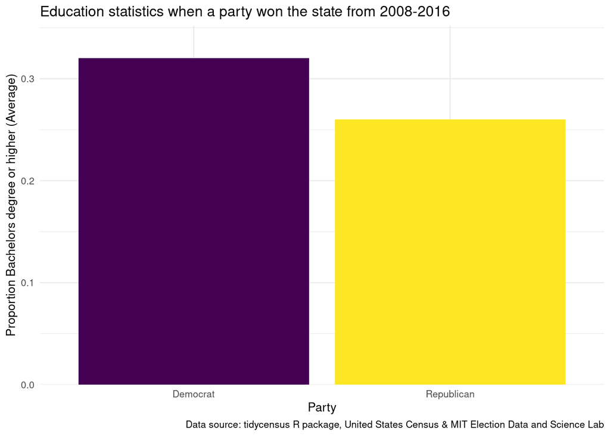

```r
# summarizing the census data for bachelors degree and higher for the parties that won the states
education_summary <- highest_by_state_year |>
  group_by(party_clean) |>
  summarise(mean_prop_college = round(mean(prop_bachelors + prop_masters + prop_doctoral + prop_professional), 2))

# plotting the above data frame
education_summary |>
  ggplot(aes(x = party_clean, y = mean_prop_college,
             fill = party_clean)) +
  geom_col() +
  labs(title = "Education statistics when a party won the state from 2008-2016",
       x = "Party", y = "Proportion Bachelors degree or higher (Average)",
       caption = "Data source: tidycensus R package, United States Census & MIT Election Data and Science Lab") +
  scale_y_continuous(expand = expansion(mult = c(0,0.1))) +
  scale_fill_viridis_d() +
  theme_minimal(base_size = 10) +
  theme(legend.position = 'none')
```

The above visualization shows states where the democratic party has had more votes have a higher proportion of those 25 years and older who have a bachelors degree or higher.

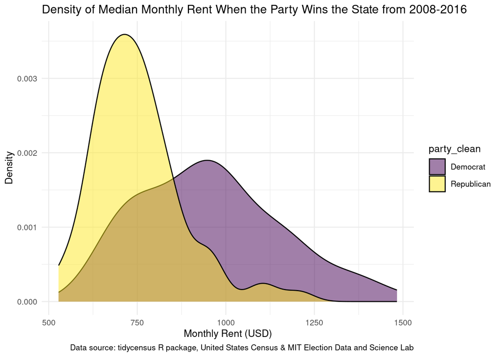

```r
# density plot for median monthly rent costs when a party won a state from 2008-2016
highest_by_state_year |>
  filter(party_clean %in% c("Democrat", "Republican")) |>
  ggplot(aes(x = median_monthly_rent_cost, fill = party_clean)) +
  geom_density(alpha = 0.5) +
  labs(title = "Density of Median Monthly Rent When the Party Wins the State from 2008-2016",
       x = "Monthly Rent (USD)", y = "Density",
       caption = "Data source: tidycensus R package, United States Census & MIT Election Data and Science Lab") +
  scale_fill_viridis_d() +
  theme_minimal(base_size = 10)
```

The above visualization shows that the median monthly rent appears to be higher in states where the democratic party has had more votes than the republican party.

[figure not shown]

```r
ggplot(decade_summary, aes(x = election_decade, y = total_votes, fill = party_simplified)) +
  geom_col(position = "stack") +
  labs(
    title = "Total Presidential Candidate Votes by Decade",
    x = "Election Decade",
    y = "Total Votes",
    fill = "Party",
  caption = "Data Source: MIT Election Data and Science Lab") +
  scale_y_continuous(expand = expansion(mult = c(0,0.1))) +
  scale_fill_viridis_d() +
  theme_minimal()
```

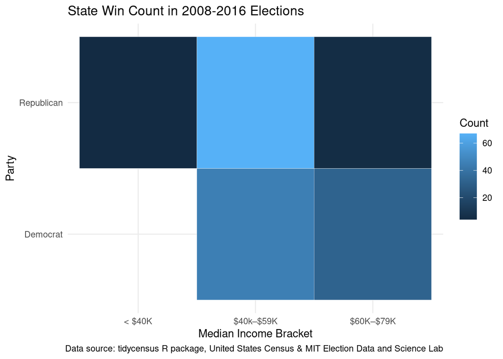

```r
highest_by_state_year |>
  group_by(party_clean) |>
  count(income_bracket) |>
  ggplot(aes(x = income_bracket, y = party_clean, fill = n)) +
  geom_tile(color = "white") +
  labs(
    title = "State Win Count in 2008-2016 Elections",
    x = "Median Income Bracket",
    y = "Party",
    fill = "Count",
    caption = "Data source: tidycensus R package, United States Census & MIT Election Data and Science Lab"
  ) +
  theme_minimal()
```

The above visualization shows the counts of median income brackets in states where the democratic party or republican party had more votes for that election. The republican party had the most wins in the 40k-59k income bracket, while the democratic party had no wins with a median income less than 40k.

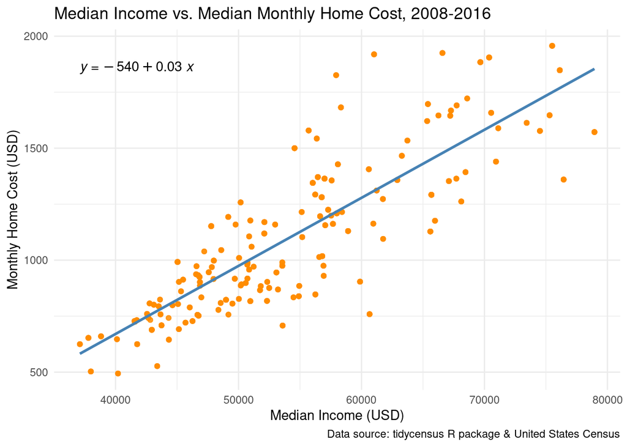

```r
#
data |>
  ggplot(aes(x = median_income, y = median_monthly_home_cost)) +
  geom_point(alpha = 0.6, color = "darkorange") +
  geom_smooth(method = "lm", se = FALSE, color = "steelblue") +
  stat_regline_equation(
    aes(label = ..eq.label..),
    label.y = max(data$median_monthly_home_cost, na.rm = TRUE) * 0.95,
    output.type = "expression",
    formula = y ~ x
  ) +
  labs(
    title = "Median Income vs. Median Monthly Home Cost, 2008-2016",
    x = "Median Income (USD)",
    y = "Monthly Home Cost (USD)",
    caption = "Data source: tidycensus R package & United States Census"
  ) +
  theme_minimal()
```

The above visualization shows what appears to be a moderate positive relationship between median income and monthly home costs from 2008 to 2016.

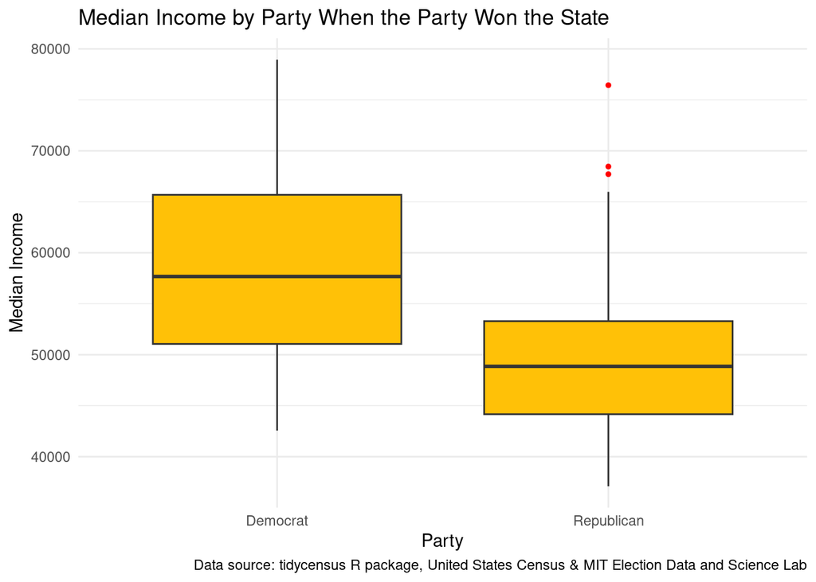

```r
# box plot showing distributions of of median incomes when a party wins a state
highest_by_state_year |>
  group_by(party_clean) |>
  ggplot(aes(x = party_clean, y = median_income )) +
  geom_boxplot(fill = "#ffc107", outlier.color = "red", outlier.size = 1) +
  labs(
    title = "Median Income by Party When the Party Won the State",
    x = "Party",
    y = "Median Income",
    caption = "Data source: tidycensus R package, United States Census & MIT Election Data and Science Lab"
  ) +
  theme_minimal()
```

The above visualization shows information about the median income for the democratic and republican parties using state data from when that party had a higher number of votes than other parties. The distribution of median income appears to be generally higher for the democratic party. The republican party did have a few outliers on the higher side of the median incomes.

#### Map showing state voting participation percentages and winning party

Data source: `state.center` data set from `datasets` R package, tidycensus R package, United States Census & MIT Election Data and Science Lab

```r
# Reference: https://rstudio.github.io/leaflet/articles/widget.html
# Reference: https://rstudio.github.io/leaflet/articles/leaflet.html
# Reference: https://rstudio.github.io/leaflet/articles/markers.html
# Reference:https://stringr.tidyverse.org/reference/str_glue.html

# state lat and long info into a usuable data frame
stateinfo <- data.frame(state.center)

state_names <- data.frame(unique(data$county_state))

state_names <- state_names |>
  mutate(state = unique.data.county_state.) |>
  select(state) |>
  filter(!(state == "district of columbia"))

stateinfo <- stateinfo |>
  mutate(state = state_names$state)

# extracting information needed from census and election information
voting_map <- highest_by_state_year |>
  filter(!(county_state == "district of columbia"), year == 2008) |>
  group_by(county_state, party_clean) |>
  mutate(prop_votes_to_population = totalvotes / population)

#joining voting information with state location information
voting_map <- left_join(stateinfo, voting_map, by = c("state" = "county_state"))

voting_map <- voting_map |>
  mutate(longitude = x,
         latitude = y)

# creating leaflet visualization
pal <-  colorFactor(c("navy", "red"), domain = c("Democrat", "Republican"))

leaflet(voting_map) |>
  addTiles() |>
    addCircleMarkers(label = str_glue("{str_to_title(voting_map$state)}", ": ", "{100 * round(voting_map$prop_votes_to_population, 2)}", "%"),
                     color = ~pal(voting_map$party_clean),
                     radius = (voting_map$prop_votes_to_population) * 30,
                     fillOpacity = (voting_map$prop_votes_to_population))
```

[interactive chart not shown]

The above visualization shows what party had the most votes for the state in 2008 (red = republican, blue = democratic). Hovering over the circle markers shows the percentage of the population in the state who participated in the presidential election. The size of the circle markers also changes with the percentage.

## Monte Carlo Methods of Inference

### Permutation Test/Randomization Test

$$H_0: \mu_{\text{R}} = \mu_{\text{D}}$$
$$H_0: \mu_{\text{R}} \neq \mu_{\text{D}}$$

where $\mu_{\text{R}}$ is the average proportion of those 25 and older in the state where the Republican party won (most votes) in the presidential election, and $\mu_{\text{D}}$ is the average proportion of those 25 and older in the state where the Democratic party won (most votes) in the presidential election.

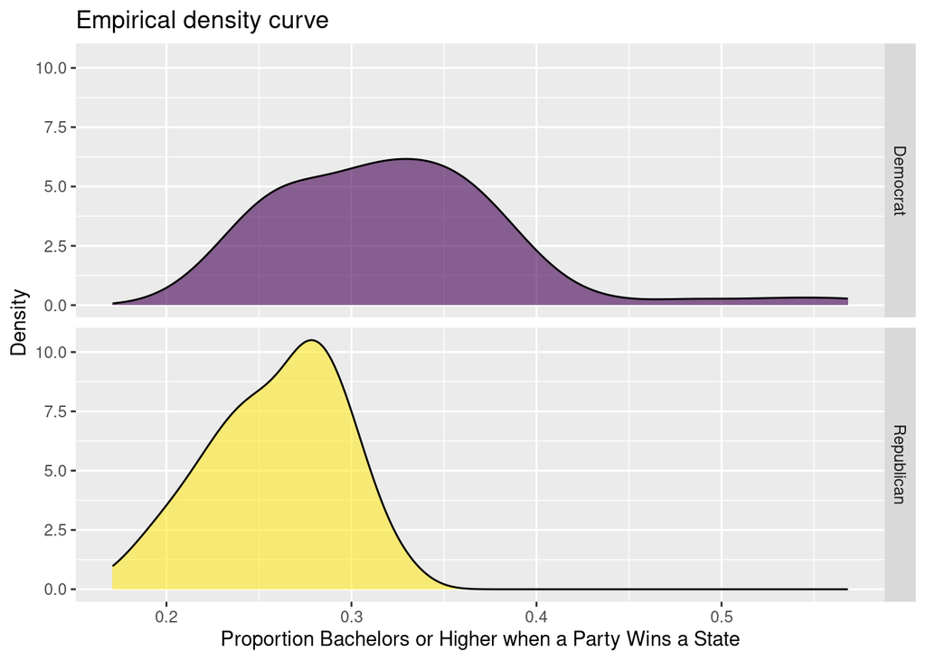

```r
# gathering trial data
trial_data <- highest_by_state_year |>
  ungroup() |>
  mutate(bach_higher = prop_bachelors + prop_masters + prop_doctoral + prop_professional) |>
  select(party_clean, bach_higher)

# density plots
highest_by_state_year |>
  group_by(party_clean) |>
  ggplot(aes(x = prop_bachelors + prop_masters + prop_doctoral + prop_professional,
             fill = party_clean)) +
  geom_density(color = "black", alpha = 0.6) +
  scale_fill_viridis_d() +
  facet_grid(party_clean ~ .) +
    labs(x = "Proportion Bachelors or Higher when a Party Wins a State",
         title = "Empirical density curve",
         y = "Density") +
  theme(legend.position = "none")
```

```r
# Calculating standard deviations and variances for each group
highest_by_state_year |>
  group_by(party_clean) |>
  summarize(Mean = mean(prop_bachelors + prop_masters + prop_doctoral + prop_professional),
            n = n(),
            SD = sd(prop_bachelors + prop_masters + prop_doctoral + prop_professional),
            Variance = var(prop_bachelors + prop_masters + prop_doctoral + prop_professional)) |>
  flextable() |>
  colformat_double(digits = 3) |>
  autofit()
```

| party_clean | Mean | n | SD | Variance |
| --- | --- | --- | --- | --- |
| Democrat | 0.322 | 77 | 0.064 | 0.004 |
| Republican | 0.259 | 76 | 0.036 | 0.001 |

```r
set.seed(123)
# Reorder factor levels
trial_data <- trial_data |>
  dplyr::mutate(party_clean = fct_relevel(party_clean, "Republican", "Democrat"))

# Two-sample t-test
ttest_result <- t.test(formula = bach_higher ~ party_clean,
                       data = trial_data,
                       alternative = "two.sided")

# Number of permutations to do
n_permutations <- 5000

# Instantiating vector for test statistics
permutation_statistics <- vector(length = n_permutations)

# Calculating t-test statistic for each permutation
for(p in 1:n_permutations) {
  permutation_statistics[p] <- t.test(formula = bach_higher ~ party_clean,
                                      alternative = "two.sided",
                                      data = trial_data |>
    mutate(party_clean = sample(party_clean, replace = FALSE))) |>
    broom::tidy() |>
    pull(statistic)
}
```

```r
janitor::tabyl(permutation_statistics > ttest_result$statistic) |>
  flextable()
```

| permutation_statistics > ttest_result$statistic | n | percent |
| --- | --- | --- |
| TRUE | 5,000 | 1 |

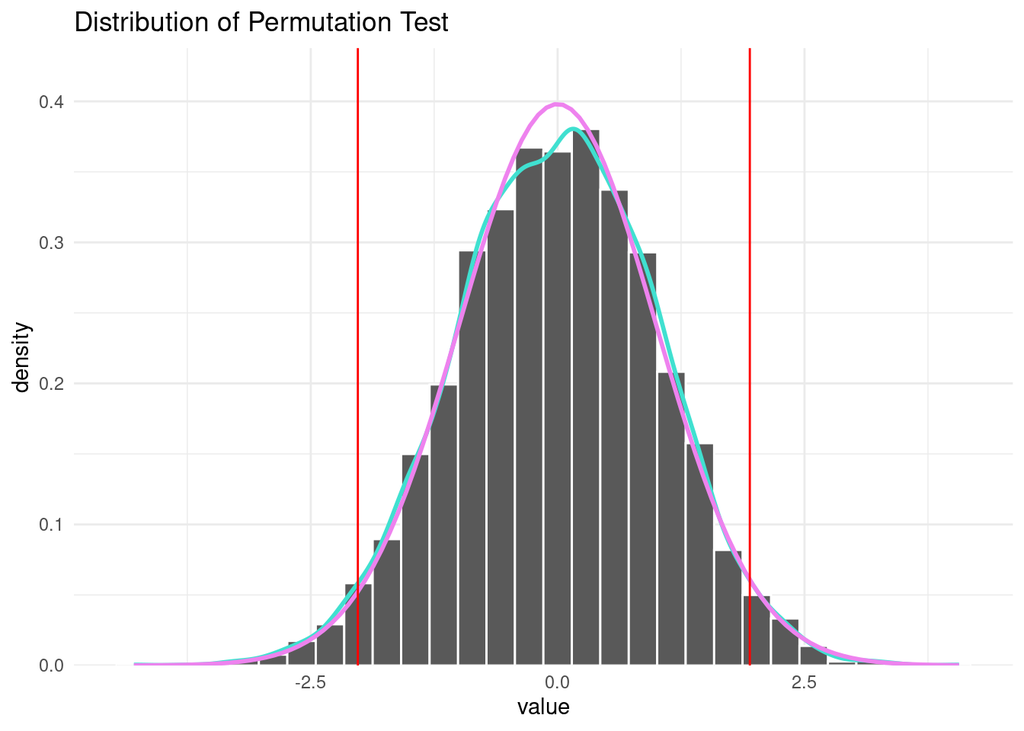

```r
tidy_statistics <- tibble(value = permutation_statistics)

tidy_statistics |>
  ggplot(aes(x = value)) +
  geom_histogram(aes(y = after_stat(density)),color = "white") +
  geom_density(color = "turquoise", linewidth = 1) +
  stat_function(fun = function(x) dt(x, df = ttest_result$parameter),
                color = "violet", linewidth = 1) +
  scale_y_continuous(expand = expansion(mult = c(0, 0.1))) +
  geom_vline(xintercept = quantile(permutation_statistics, probs = 0.025),
             color = "red") +
  geom_vline(xintercept = quantile(permutation_statistics, probs = 0.975),
             color = "red") +
  labs(title = "Distribution of Permutation Test") +
  theme_minimal()
```

**Interpretation in context**: We have sufficient evidence at the 5% significance level that the average proportion of those 25 and older in the state where the Republican party won (most votes) in the presidential election differs from the average proportion of those 25 and older in the state where the Democratic party won (most votes) in the presidential election.

```r
# median income difference between two parties Democrats vs. Republicans — using a permutation test

# Filtering to just Democrat and Republican entries with available income
perm_data <- data |>
  filter(party_clean %in% c("Democrat", "Republican")) |>
  select(party_clean, median_income)

# Observed difference in means
obs_diff <- perm_data |>
  group_by(party_clean) |>
  summarise(mean_income = mean(median_income), .groups = "drop") |>
  summarise(diff = diff(mean_income)) |>
  pull(diff)
```

```r
# Permutation test setup
set.seed(123)
B <- 5000  # Number of permutations

perm_diffs <- replicate(B, {
  shuffled_party <- sample(perm_data$party_clean)
  permuted <- perm_data |>
    mutate(party_perm = shuffled_party) |>
    group_by(party_perm) |>
    summarise(mean_income = mean(median_income), .groups = "drop") |>
    summarise(diff = diff(mean_income)) |>
    pull(diff)
})

# p-value (two-sided)
p_val <- mean(abs(perm_diffs) >= abs(obs_diff))

# Print results
cat("Observed difference in mean income:", round(obs_diff, 2), "\n")
```

```
Observed difference in mean income: 4.37
```

```r
cat("Permutation test p-value:", round(p_val, 4), "\n")
```

```
Permutation test p-value: 0.997
```

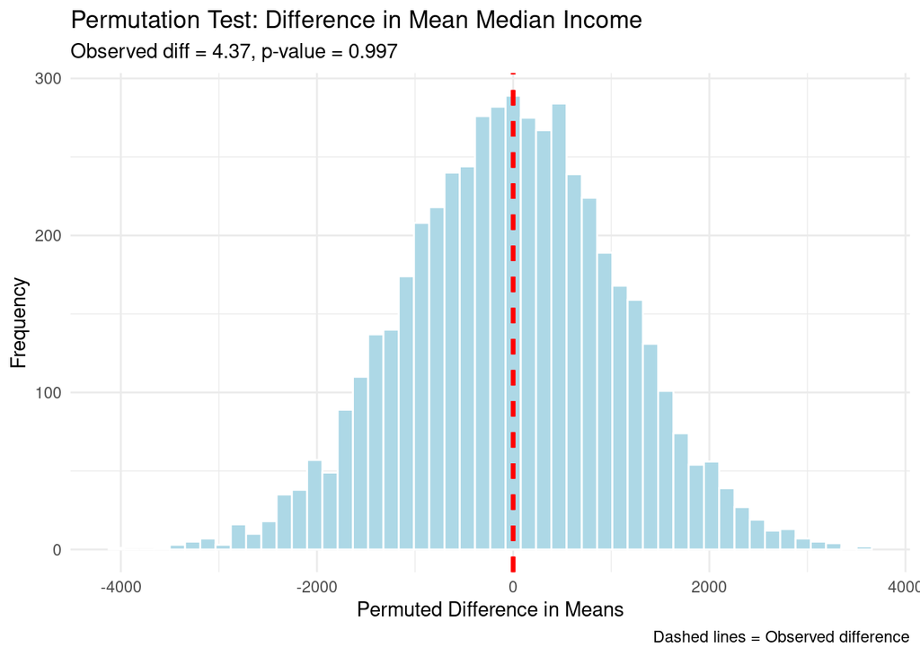

```r
tibble(perm_diffs = perm_diffs) |>
  ggplot(aes(x = perm_diffs)) +
  geom_histogram(fill = "lightblue", bins = 50, color = "white") +
  geom_vline(xintercept = obs_diff, color = "red", linetype = "dashed", size = 1) +
  geom_vline(xintercept = -obs_diff, color = "red", linetype = "dashed", size = 1) +
  labs(
    title = "Permutation Test: Difference in Mean Median Income",
    subtitle = paste0("Observed diff = ", round(obs_diff, 2), ", p-value = ", round(p_val, 4)),
    x = "Permuted Difference in Means",
    y = "Frequency",
    caption = "Dashed lines = Observed difference",
  ) +
  theme_minimal()
```